# Project: Investigate a Dataset - [TMDB 5000 Movie]

- Introduction
- Data Wrangling
- Exploratory Data Analysis
- Conclusions

## Introduction

### TMDB 5000 Movie Dataset Description

> What can we say about the success of a movie before it is released? Are there certain companies (Pixar?) that have found a consistent formula? Given that major films costing over$100 million to produce can still flop, this question is more important than ever to the industry. Film aficionados might have different interests. Can we predict which films will be highly rated, whether or not they are a commercial success? This is a great place to start digging in to those questions, with data on the plot, cast, crew, budget, and revenues of several thousand films.

### Question(s) for Analysis

> - **Q1** Which month had the most number of movies released on it?
> - **Q2** What is the popular vote average for the movies?
> - **Q3** How many number of the movies get good result of the vote rate(Including number of gains and losses?
> - **Q4** What is the most common runtime interval for all movies?
> - **Q5** What is the most genre popular?
> - **Q6** Was there a change in the number of movies released over time?

```python
import pandas as pd
import numpy as np
import matplotlib.pyplot as plt
import seaborn as sn
%matplotlib inline
```

## Data Wrangling

```python
#Read dataset of medical appointments
df=pd.read_csv('tmdb-movies (1).csv')

pd.set_option("max_columns", None) # show all cols
pd.set_option('max_colwidth', None) # show full width of showing cols
pd.set_option("expand_frame_repr", False) # print cols side by side as it's supposed to be

df.head(50)
```

[output not shown]

```python
df.tail(50)
```

[output not shown]

```python
df.info()
```

```
<class 'pandas.core.frame.DataFrame'>
RangeIndex: 10866 entries, 0 to 10865
Data columns (total 21 columns):
 #   Column                Non-Null Count  Dtype
---  ------                --------------  -----
 0   id                    10866 non-null  int64
 1   imdb_id               10856 non-null  object
 2   popularity            10866 non-null  float64
 3   budget                10866 non-null  int64
 4   revenue               10866 non-null  int64
 5   original_title        10866 non-null  object
 6   cast                  10790 non-null  object
 7   homepage              2936 non-null   object
 8   director              10822 non-null  object
 9   tagline               8042 non-null   object
 10  keywords              9373 non-null   object
 11  overview              10862 non-null  object
 12  runtime               10866 non-null  int64
 13  genres                10843 non-null  object
 14  production_companies  9836 non-null   object
 15  release_date          10866 non-null  object
 16  vote_count            10866 non-null  int64
 17  vote_average          10866 non-null  float64
 18  release_year          10866 non-null  int64
 19  budget_adj            10866 non-null  float64
 20  revenue_adj           10866 non-null  float64
dtypes: float64(4), int64(6), object(11)
memory usage: 1.7+ MB
```

```python
df.shape
```

```
(10866, 21)
```

```python
df.describe()
```

|  | id | popularity | budget | revenue | runtime | vote_count | vote_average | release_year | budget_adj | revenue_adj |
| --- | --- | --- | --- | --- | --- | --- | --- | --- | --- | --- |
| count | 10866.000000 | 10866.000000 | 1.086600e+04 | 1.086600e+04 | 10866.000000 | 10866.000000 | 10866.000000 | 10866.000000 | 1.086600e+04 | 1.086600e+04 |
| mean | 66064.177434 | 0.646441 | 1.462570e+07 | 3.982332e+07 | 102.070863 | 217.389748 | 5.974922 | 2001.322658 | 1.755104e+07 | 5.136436e+07 |
| std | 92130.136561 | 1.000185 | 3.091321e+07 | 1.170035e+08 | 31.381405 | 575.619058 | 0.935142 | 12.812941 | 3.430616e+07 | 1.446325e+08 |
| min | 5.000000 | 0.000065 | 0.000000e+00 | 0.000000e+00 | 0.000000 | 10.000000 | 1.500000 | 1960.000000 | 0.000000e+00 | 0.000000e+00 |
| 25% | 10596.250000 | 0.207583 | 0.000000e+00 | 0.000000e+00 | 90.000000 | 17.000000 | 5.400000 | 1995.000000 | 0.000000e+00 | 0.000000e+00 |
| 50% | 20669.000000 | 0.383856 | 0.000000e+00 | 0.000000e+00 | 99.000000 | 38.000000 | 6.000000 | 2006.000000 | 0.000000e+00 | 0.000000e+00 |
| 75% | 75610.000000 | 0.713817 | 1.500000e+07 | 2.400000e+07 | 111.000000 | 145.750000 | 6.600000 | 2011.000000 | 2.085325e+07 | 3.369710e+07 |
| max | 417859.000000 | 32.985763 | 4.250000e+08 | 2.781506e+09 | 900.000000 | 9767.000000 | 9.200000 | 2015.000000 | 4.250000e+08 | 2.827124e+09 |

```python
df.dtypes
```

```
id                        int64
imdb_id                  object
popularity              float64
budget                    int64
revenue                   int64
original_title           object
cast                     object
homepage                 object
director                 object
tagline                  object
keywords                 object
overview                 object
runtime                   int64
genres                   object
production_companies     object
release_date             object
vote_count                int64
vote_average            float64
release_year              int64
budget_adj              float64
revenue_adj             float64
dtype: object
```

### Data Cleaning

```python
# Change datatype
df['release_date'] = pd.to_datetime(df['release_date'])
df['release_date'].dtype.type

df['popularity'] = df['popularity'].astype('int32')
```

```python
#Finding duplicated values in a DataFrame
df.duplicated().any()
df.duplicated()

df['id'].is_unique
duplicate = df[df.duplicated('id')]

# Print the resultant Dataframe
duplicate
```

|  | id | imdb_id | popularity | budget | revenue | original_title | cast | homepage | director | tagline | keywords | overview | runtime | genres | production_companies | release_date | vote_count | vote_average | release_year | budget_adj | revenue_adj |
| --- | --- | --- | --- | --- | --- | --- | --- | --- | --- | --- | --- | --- | --- | --- | --- | --- | --- | --- | --- | --- | --- |
| 2090 | 42194 | tt0411951 | 0 | 30000000 | 967000 | TEKKEN | Jon Foo\|Kelly Overton\|Cary-Hiroyuki Tagawa\|Ian Anthony Dale\|Luke Goss | NaN | Dwight H. Little | Survival is no game | martial arts\|dystopia\|based on video game\|martial arts tournament | In the year of 2039, after World Wars destroy much of the civilization as we know it, territories are no longer run by governments, but by corporations; the mightiest of which is the Mishima Zaibatsu.… | 92 | Crime\|Drama\|Action\|Thriller\|Science Fiction | Namco\|Light Song Films | 2010-03-20 | 110 | 5.0 | 2010 | 30000000.0 | 967000.0 |

```python
# Finding missing elements in a DataFrame
df.isnull()
df.isna().any()
df.isna().sum()

df.fillna({'imdb_id':'Not Stated','cast':'Not Stated','homepage':'Not Stated','director':'Not Stated','tagline':'Not Stated',
           'overview':'Not Stated','genres':'Not Stated','production_companies':'Not Stated','keywords':0}, inplace=True)


df.loc[df['cast']=='Not Stated']
```

|  | id | imdb_id | popularity | budget | revenue | original_title | cast | homepage | director | tagline | keywords | overview | runtime | genres | production_companies | release_date | vote_count | vote_average | release_year | budget_adj | revenue_adj |
| --- | --- | --- | --- | --- | --- | --- | --- | --- | --- | --- | --- | --- | --- | --- | --- | --- | --- | --- | --- | --- | --- |
| 371 | 345637 | tt4661600 | 0 | 0 | 0 | Sanjay's Super Team | Not Stated | Not Stated | Sanjay Patel | Not Stated | 0 | Sanjay's Super Team follows the daydream of a young Indian boy, bored with his father's religious meditation, who imagines "a kind of ancient, Hindu version of The Avengers, with the gods appearing li… | 7 | Animation | Pixar Animation Studios | 2015-11-25 | 47 | 6.9 | 2015 | 0.000000 | 0.0 |
| 441 | 355020 | tt4908644 | 0 | 0 | 0 | Winter on Fire: Ukraine's Fight for Freedom | Not Stated | http://www.netflix.com/title/80031666 | Evgeny Afineevsky | The Next Generation Of Revolution | 0 | A documentary on the unrest in Ukraine during 2013 and 2014, as student demonstrations supporting European integration grew into a violent revolution calling for the resignation of President Viktor F.… | 98 | Documentary | Passion Pictures\|Campbell Grobman Films\|Afineevsky - Tolmor Production\|Pray for Ukraine Production\|Rock Paper Scissors | 2015-10-09 | 37 | 8.2 | 2015 | 0.000000 | 0.0 |
| 465 | 321109 | tt4393514 | 0 | 0 | 0 | Bitter Lake | Not Stated | Not Stated | Adam Curtis | Not Stated | manipulation\|politics\|war\|control\|fear | An experimental documentary that explores Saudi Arabia's relationship with the U.S. and the role this has played in the war in Afghanistan. | 135 | Documentary | BBC | 2015-01-24 | 19 | 7.8 | 2015 | 0.000000 | 0.0 |
| 536 | 333350 | tt3762974 | 0 | 0 | 0 | A Faster Horse | Not Stated | Not Stated | David Gelb | Not Stated | mustang\|car\|corporation\|henry ford family\|car factory | David Gelb (Jiro Dreams of Sushi) tackles another venerable, beloved, and long-standing institution: the Mustang, crown jewel of the Ford fleet. Only this institution is in turmoil. As the fiftieth an… | 90 | Documentary | Not Stated | 2015-10-08 | 12 | 8.0 | 2015 | 0.000000 | 0.0 |
| 538 | 224972 | tt3983674 | 0 | 0 | 0 | The Mask You Live In | Not Stated | http://themaskyoulivein.org | Jennifer Siebel Newsom | Is american masculinity harming our boys, men and society at large? | feminism\|sexism\|young boy\|gender roles\|misogyny | Compared to girls, research shows that boys in the U.S. are more likely to be diagnosed with a behavior disorder, prescribed stimulant medications, fail out of school, binge drink, commit a violent cr… | 88 | Documentary | Not Stated | 2015-01-01 | 11 | 8.9 | 2015 | 0.000000 | 0.0 |
| ... | ... | ... | ... | ... | ... | ... | ... | ... | ... | ... | ... | ... | ... | ... | ... | ... | ... | ... | ... | ... | ... |
| 9677 | 13926 | tt0093832 | 0 | 0 | 0 | Red's Dream | Not Stated | Not Stated | John Lasseter | Not Stated | 0 | Life as the sole sale item in the clearance corner of Eben's Bikes can get lonely. So Red, a unicycle, dreams up a clown owner and his own juggling act that steals the show. But all too soon, the appl… | 4 | Animation | Pixar Animation Studios | 1987-08-17 | 44 | 6.6 | 1987 | 0.000000 | 0.0 |
| 9755 | 48714 | tt0061402 | 0 | 0 | 0 | The Big Shave | Not Stated | Not Stated | Martin Scorsese | Not Stated | 0 | This short film is a metaphor for the Vietnam War. A man walks into a meticulously clean and sterile bathroom, concentrating on the polished porcelain and shiny metal motif. He then proceeds to shave.… | 6 | Drama | Not Stated | 2068-01-01 | 12 | 6.7 | 1968 | 0.000000 | 0.0 |
| 10434 | 48784 | tt0060984 | 0 | 200 | 0 | Six Men Getting Sick | Not Stated | Not Stated | David Lynch | Not Stated | student movie\|short | Lynch's first film project consists of a loop of six people vomiting projected on to a special sculptured screen featuring twisted three-dimensional faces. | 4 | Animation | Pensylvania Academy of Fine Arts | 2067-01-01 | 16 | 5.2 | 1967 | 1307.352748 | 0.0 |
| 10550 | 13925 | tt0091455 | 0 | 0 | 0 | Luxo Jr. | Not Stated | http://www.pixar.com/short_films/Theatrical-Shorts/Luxo-Jr. | John Lasseter | Not Stated | pixar animated short\|luxo lamps\|beach ball\|father and child | A baby lamp finds a ball to play with and it's all fun and games until the ball bursts. Just when the elder Luxo thinks his kid will settle down for a bit, Luxo Jr. finds a ball ten times bigger. | 2 | Animation\|Family | Pixar Animation Studios | 1986-08-17 | 81 | 7.3 | 1986 | 0.000000 | 0.0 |
| 10754 | 3171 | tt0064064 | 0 | 0 | 0 | Bambi Meets Godzilla | Not Stated | Not Stated | Marv Newland | Not Stated | roe | Bambi is nibbling the grass, unaware of the upcoming encounter with Godzilla. Who will win when they finally meet? | 2 | Animation\|Comedy | Not Stated | 2069-01-01 | 12 | 5.6 | 1969 | 0.000000 | 0.0 |

76 rows × 21 columns

```python
#Dropping Columns in a DataFrame
>>> to_drop = ['cast',
...            'homepage',
...            'tagline',
...            'overview',
...            'budget_adj',
...            'revenue_adj',
                "keywords"]

>>> df.drop(to_drop, inplace=True, axis=1)
```

```python
# delete all rows with column 'production_companies' has value "Not Stated"
index_production_companies = df[df['production_companies'] == "Not Stated"].index
df.drop(index_production_companies , inplace=True)
```

```python
df.head(50)
```

|  | id | imdb_id | popularity | budget | revenue | original_title | director | runtime | genres | production_companies | release_date | vote_count | vote_average | release_year |
| --- | --- | --- | --- | --- | --- | --- | --- | --- | --- | --- | --- | --- | --- | --- |
| 0 | 135397 | tt0369610 | 32 | 150000000 | 1513528810 | Jurassic World | Colin Trevorrow | 124 | Action\|Adventure\|Science Fiction\|Thriller | Universal Studios\|Amblin Entertainment\|Legendary Pictures\|Fuji Television Network\|Dentsu | 2015-06-09 | 5562 | 6.5 | 2015 |
| 1 | 76341 | tt1392190 | 28 | 150000000 | 378436354 | Mad Max: Fury Road | George Miller | 120 | Action\|Adventure\|Science Fiction\|Thriller | Village Roadshow Pictures\|Kennedy Miller Productions | 2015-05-13 | 6185 | 7.1 | 2015 |
| 2 | 262500 | tt2908446 | 13 | 110000000 | 295238201 | Insurgent | Robert Schwentke | 119 | Adventure\|Science Fiction\|Thriller | Summit Entertainment\|Mandeville Films\|Red Wagon Entertainment\|NeoReel | 2015-03-18 | 2480 | 6.3 | 2015 |
| 3 | 140607 | tt2488496 | 11 | 200000000 | 2068178225 | Star Wars: The Force Awakens | J.J. Abrams | 136 | Action\|Adventure\|Science Fiction\|Fantasy | Lucasfilm\|Truenorth Productions\|Bad Robot | 2015-12-15 | 5292 | 7.5 | 2015 |
| 4 | 168259 | tt2820852 | 9 | 190000000 | 1506249360 | Furious 7 | James Wan | 137 | Action\|Crime\|Thriller | Universal Pictures\|Original Film\|Media Rights Capital\|Dentsu\|One Race Films | 2015-04-01 | 2947 | 7.3 | 2015 |
| 5 | 281957 | tt1663202 | 9 | 135000000 | 532950503 | The Revenant | Alejandro González Iñárritu | 156 | Western\|Drama\|Adventure\|Thriller | Regency Enterprises\|Appian Way\|CatchPlay\|Anonymous Content\|New Regency Pictures | 2015-12-25 | 3929 | 7.2 | 2015 |
| 6 | 87101 | tt1340138 | 8 | 155000000 | 440603537 | Terminator Genisys | Alan Taylor | 125 | Science Fiction\|Action\|Thriller\|Adventure | Paramount Pictures\|Skydance Productions | 2015-06-23 | 2598 | 5.8 | 2015 |
| 7 | 286217 | tt3659388 | 7 | 108000000 | 595380321 | The Martian | Ridley Scott | 141 | Drama\|Adventure\|Science Fiction | Twentieth Century Fox Film Corporation\|Scott Free Productions\|Mid Atlantic Films\|International Traders\|TSG Entertainment | 2015-09-30 | 4572 | 7.6 | 2015 |
| 8 | 211672 | tt2293640 | 7 | 74000000 | 1156730962 | Minions | Kyle Balda\|Pierre Coffin | 91 | Family\|Animation\|Adventure\|Comedy | Universal Pictures\|Illumination Entertainment | 2015-06-17 | 2893 | 6.5 | 2015 |
| 9 | 150540 | tt2096673 | 6 | 175000000 | 853708609 | Inside Out | Pete Docter | 94 | Comedy\|Animation\|Family | Walt Disney Pictures\|Pixar Animation Studios\|Walt Disney Studios Motion Pictures | 2015-06-09 | 3935 | 8.0 | 2015 |
| 10 | 206647 | tt2379713 | 6 | 245000000 | 880674609 | Spectre | Sam Mendes | 148 | Action\|Adventure\|Crime | Columbia Pictures\|Danjaq\|B24 | 2015-10-26 | 3254 | 6.2 | 2015 |
| 11 | 76757 | tt1617661 | 6 | 176000003 | 183987723 | Jupiter Ascending | Lana Wachowski\|Lilly Wachowski | 124 | Science Fiction\|Fantasy\|Action\|Adventure | Village Roadshow Pictures\|Dune Entertainment\|Anarchos Productions\|Warner Bros. | 2015-02-04 | 1937 | 5.2 | 2015 |
| 12 | 264660 | tt0470752 | 6 | 15000000 | 36869414 | Ex Machina | Alex Garland | 108 | Drama\|Science Fiction | DNA Films\|Universal Pictures International (UPI)\|Film4 | 2015-01-21 | 2854 | 7.6 | 2015 |
| 13 | 257344 | tt2120120 | 5 | 88000000 | 243637091 | Pixels | Chris Columbus | 105 | Action\|Comedy\|Science Fiction | Columbia Pictures\|Happy Madison Productions | 2015-07-16 | 1575 | 5.8 | 2015 |
| 14 | 99861 | tt2395427 | 5 | 280000000 | 1405035767 | Avengers: Age of Ultron | Joss Whedon | 141 | Action\|Adventure\|Science Fiction | Marvel Studios\|Prime Focus\|Revolution Sun Studios | 2015-04-22 | 4304 | 7.4 | 2015 |
| 15 | 273248 | tt3460252 | 5 | 44000000 | 155760117 | The Hateful Eight | Quentin Tarantino | 167 | Crime\|Drama\|Mystery\|Western | Double Feature Films\|The Weinstein Company\|FilmColony | 2015-12-25 | 2389 | 7.4 | 2015 |
| 16 | 260346 | tt2446042 | 5 | 48000000 | 325771424 | Taken 3 | Olivier Megaton | 109 | Crime\|Action\|Thriller | Twentieth Century Fox Film Corporation\|M6 Films\|Canal+\|EuropaCorp\|Ciné+ | 2015-01-01 | 1578 | 6.1 | 2015 |
| 17 | 102899 | tt0478970 | 5 | 130000000 | 518602163 | Ant-Man | Peyton Reed | 115 | Science Fiction\|Action\|Adventure | Marvel Studios | 2015-07-14 | 3779 | 7.0 | 2015 |
| 18 | 150689 | tt1661199 | 5 | 95000000 | 542351353 | Cinderella | Kenneth Branagh | 112 | Romance\|Fantasy\|Family\|Drama | Walt Disney Pictures\|Genre Films\|Beagle Pug Films\|Allison Shearmur Productions | 2015-03-12 | 1495 | 6.8 | 2015 |
| 19 | 131634 | tt1951266 | 5 | 160000000 | 650523427 | The Hunger Games: Mockingjay - Part 2 | Francis Lawrence | 136 | War\|Adventure\|Science Fiction | Studio Babelsberg\|StudioCanal\|Lionsgate\|Walt Disney Studios Motion Pictures\|Color Force | 2015-11-18 | 2380 | 6.5 | 2015 |
| 20 | 158852 | tt1964418 | 5 | 190000000 | 209035668 | Tomorrowland | Brad Bird | 130 | Action\|Family\|Science Fiction\|Adventure\|Mystery | Walt Disney Pictures\|Babieka\|A113 | 2015-05-19 | 1899 | 6.2 | 2015 |
| 21 | 307081 | tt1798684 | 5 | 30000000 | 91709827 | Southpaw | Antoine Fuqua | 123 | Action\|Drama | Escape Artists\|Riche-Ludwig Productions | 2015-06-15 | 1386 | 7.3 | 2015 |
| 22 | 254128 | tt2126355 | 4 | 110000000 | 470490832 | San Andreas | Brad Peyton | 114 | Action\|Drama\|Thriller | New Line Cinema\|Village Roadshow Pictures\|Warner Bros.\|Flynn Picture Company | 2015-05-27 | 2060 | 6.1 | 2015 |
| 23 | 216015 | tt2322441 | 4 | 40000000 | 569651467 | Fifty Shades of Grey | Sam Taylor-Johnson | 125 | Drama\|Romance | Focus Features\|Trigger Street Productions\|Michael De Luca Productions | 2015-02-11 | 1865 | 5.3 | 2015 |
| 24 | 318846 | tt1596363 | 4 | 28000000 | 133346506 | The Big Short | Adam McKay | 130 | Comedy\|Drama | Paramount Pictures\|Plan B Entertainment\|Regency Enterprises | 2015-12-11 | 1545 | 7.3 | 2015 |
| 25 | 177677 | tt2381249 | 4 | 150000000 | 682330139 | Mission: Impossible - Rogue Nation | Christopher McQuarrie | 131 | Action | Paramount Pictures\|Skydance Productions\|China Movie Channel\|Bad Robot\|TC Productions | 2015-07-23 | 2349 | 7.1 | 2015 |
| 26 | 214756 | tt2637276 | 4 | 68000000 | 215863606 | Ted 2 | Seth MacFarlane | 115 | Comedy | Universal Pictures\|Media Rights Capital\|Fuzzy Door Productions | 2015-06-25 | 1666 | 6.3 | 2015 |
| 27 | 207703 | tt2802144 | 4 | 81000000 | 403802136 | Kingsman: The Secret Service | Matthew Vaughn | 130 | Crime\|Comedy\|Action\|Adventure | Twentieth Century Fox Film Corporation\|Marv Films\|TSG Entertainment\|Cloudy Productions | 2015-01-24 | 3833 | 7.6 | 2015 |
| 28 | 314365 | tt1895587 | 4 | 20000000 | 88346473 | Spotlight | Tom McCarthy | 128 | Drama\|Thriller\|History | Participant Media\|Open Road Films\|Anonymous Content\|Rocklin / Faust\|Entertainment One Features | 2015-11-06 | 1559 | 7.8 | 2015 |
| 29 | 294254 | tt4046784 | 3 | 61000000 | 311256926 | Maze Runner: The Scorch Trials | Wes Ball | 132 | Action\|Science Fiction\|Thriller | Gotham Group\|Temple Hill Entertainment\|TSG Entertainment | 2015-09-09 | 1849 | 6.4 | 2015 |
| 30 | 280996 | tt3168230 | 3 | 0 | 29355203 | Mr. Holmes | Bill Condon | 103 | Mystery\|Drama | BBC Films\|See-Saw Films\|FilmNation Entertainment\|Archer Gray\|AI-Film | 2015-06-19 | 425 | 6.4 | 2015 |
| 31 | 198184 | tt1823672 | 3 | 49000000 | 102069268 | Chappie | Neill Blomkamp | 120 | Crime\|Action\|Science Fiction | Columbia Pictures\|Media Rights Capital\|Sony Pictures Entertainment (SPE)\|Alpha Core\|Genre Films | 2015-03-04 | 1990 | 6.6 | 2015 |
| 32 | 254470 | tt2848292 | 3 | 29000000 | 287506194 | Pitch Perfect 2 | Elizabeth Banks | 115 | Comedy\|Music | Universal Pictures\|Gold Circle Films\|Brownstone Productions | 2015-05-07 | 1264 | 6.8 | 2015 |
| 33 | 296098 | tt3682448 | 3 | 40000000 | 162610473 | Bridge of Spies | Steven Spielberg | 141 | Thriller\|Drama | DreamWorks SKG\|Amblin Entertainment\|Studio Babelsberg\|Fox 2000 Pictures\|Marc Platt Productions | 2015-10-15 | 1638 | 7.1 | 2015 |
| 34 | 257445 | tt1051904 | 3 | 58000000 | 150170815 | Goosebumps | Rob Letterman | 103 | Adventure\|Horror\|Comedy | Columbia Pictures\|Original Film\|Scholastic Entertainment | 2015-08-05 | 600 | 6.2 | 2015 |
| 35 | 264644 | tt3170832 | 3 | 6000000 | 35401758 | Room | Lenny Abrahamson | 117 | Drama\|Thriller | Element Pictures\|No Trace Camping\|A24\|Duperele Films | 2015-10-16 | 1520 | 8.0 | 2015 |
| 36 | 339527 | tt1291570 | 3 | 0 | 22354572 | Solace | Afonso Poyart | 101 | Crime\|Drama\|Mystery | Eden Rock Media\|FilmNation Entertainment\|Flynn Picture Company | 2015-09-03 | 474 | 6.2 | 2015 |
| 37 | 105864 | tt1979388 | 3 | 175000000 | 331926147 | The Good Dinosaur | Peter Sohn | 93 | Adventure\|Animation\|Comedy\|Family\|Fantasy | Walt Disney Pictures\|Pixar Animation Studios\|Buena Vista | 2015-11-14 | 1087 | 6.6 | 2015 |
| 38 | 241554 | tt2199571 | 3 | 50000000 | 71561644 | Run All Night | Jaume Collet-Serra | 114 | Action\|Crime\|Drama\|Mystery\|Thriller | Vertigo Entertainment\|Energy Entertainment\|RatPac-Dune Entertainment | 2015-03-11 | 814 | 6.3 | 2015 |
| 39 | 167073 | tt2381111 | 3 | 11000000 | 62076141 | Brooklyn | John Crowley | 111 | Drama\|Romance | Wildgaze Films\|Irish Film Board\|Item 7\|Parallel Film Productions | 2015-11-04 | 754 | 7.3 | 2015 |
| 40 | 277216 | tt1398426 | 3 | 28000000 | 201634991 | Straight Outta Compton | F. Gary Gray | 147 | Drama\|Music | New Line Cinema\|Universal Pictures\|Legendary Pictures\|Cube Vision\|Broken Chair Flickz | 2015-08-13 | 918 | 7.7 | 2015 |
| 41 | 274854 | tt1618442 | 3 | 90000000 | 140396650 | The Last Witch Hunter | Breck Eisner | 106 | Fantasy\|Action\|Adventure | Summit Entertainment\|Atmosphere Entertainment MM\|One Race Films\|Goldmann Pictures\|NeoReel | 2015-10-21 | 879 | 5.6 | 2015 |
| 42 | 321697 | tt2080374 | 3 | 30000000 | 34441873 | Steve Jobs | Danny Boyle | 122 | History\|Drama | Universal Pictures\|Scott Rudin Productions\|Legendary Pictures\|The Mark Gordon Company\|Management 360 | 2015-10-09 | 1035 | 6.9 | 2015 |
| 43 | 203801 | tt1638355 | 3 | 75000000 | 108145109 | The Man from U.N.C.L.E. | Guy Ritchie | 116 | Comedy\|Action\|Adventure | Davis Entertainment\|Warner Bros.\|Wigram Productions\|RatPac-Dune Entertainment | 2015-08-13 | 1548 | 7.0 | 2015 |
| 44 | 293863 | tt1655441 | 3 | 25000000 | 42629776 | The Age of Adaline | Lee Toland Krieger | 112 | Fantasy\|Drama\|Romance | Lakeshore Entertainment\|Sidney Kimmel Entertainment\|Sierra/Affinity | 2015-04-16 | 1221 | 7.3 | 2015 |
| 45 | 325348 | tt3072482 | 3 | 10000000 | 14333790 | Hardcore Henry | Ilya Naishuller | 97 | Action\|Adventure\|Science Fiction | Bazelevs Production\|Versus Pictures | 2015-09-12 | 396 | 5.9 | 2015 |
| 46 | 228161 | tt2224026 | 2 | 135000000 | 368871007 | Home | Tim Johnson | 94 | Fantasy\|Comedy\|Animation\|Science Fiction\|Family | Twentieth Century Fox Film Corporation\|DreamWorks Animation | 2015-03-18 | 1060 | 6.9 | 2015 |
| 47 | 286565 | tt3622592 | 2 | 12000000 | 85512300 | Paper Towns | Jake Schreier | 109 | Drama\|Mystery\|Romance | Fox 2000 Pictures | 2015-07-09 | 1252 | 6.2 | 2015 |
| 48 | 265208 | tt2231253 | 2 | 30000000 | 0 | Wild Card | Simon West | 92 | Thriller\|Crime\|Drama | Current Entertainment\|Lionsgate\|Sierra / Affinity\|SJ Heat Productions\|Silver State Production Services | 2015-01-14 | 481 | 5.3 | 2015 |
| 49 | 254320 | tt3464902 | 2 | 4000000 | 9064511 | The Lobster | Yorgos Lanthimos | 118 | Thriller\|Comedy\|Drama\|Romance\|Science Fiction | Haut et Court\|Eurimages\|Lemming Film\|Element Pictures\|Nederlands Fonds voor de Film | 2015-10-08 | 638 | 6.6 | 2015 |

```python
#percentage of the null elements
rows, columns = df.shape
cell_count = rows * columns
number_of_nulls = df.isnull().sum().sum()
percentage_of_missing = (number_of_nulls / cell_count) * 100
print(f'Percentage of missing values: {percentage_of_missing}%')
```

```
Percentage of missing values: 0.0%
```

```python
# genres Column

def get_genre(row, genre_index):
    array_genres = row['genres'].split('|')

    if len(array_genres) == 0:
        return ''
    else:
        return array_genres[genre_index]

df['genre_1'] = df.apply(lambda row: get_genre(row, 0), axis=1)
```

```python
df.head()
```

|  | id | imdb_id | popularity | budget | revenue | original_title | director | runtime | genres | production_companies | release_date | vote_count | vote_average | release_year | genre_1 |
| --- | --- | --- | --- | --- | --- | --- | --- | --- | --- | --- | --- | --- | --- | --- | --- |
| 0 | 135397 | tt0369610 | 32 | 150000000 | 1513528810 | Jurassic World | Colin Trevorrow | 124 | Action\|Adventure\|Science Fiction\|Thriller | Universal Studios\|Amblin Entertainment\|Legendary Pictures\|Fuji Television Network\|Dentsu | 2015-06-09 | 5562 | 6.5 | 2015 | Action |
| 1 | 76341 | tt1392190 | 28 | 150000000 | 378436354 | Mad Max: Fury Road | George Miller | 120 | Action\|Adventure\|Science Fiction\|Thriller | Village Roadshow Pictures\|Kennedy Miller Productions | 2015-05-13 | 6185 | 7.1 | 2015 | Action |
| 2 | 262500 | tt2908446 | 13 | 110000000 | 295238201 | Insurgent | Robert Schwentke | 119 | Adventure\|Science Fiction\|Thriller | Summit Entertainment\|Mandeville Films\|Red Wagon Entertainment\|NeoReel | 2015-03-18 | 2480 | 6.3 | 2015 | Adventure |
| 3 | 140607 | tt2488496 | 11 | 200000000 | 2068178225 | Star Wars: The Force Awakens | J.J. Abrams | 136 | Action\|Adventure\|Science Fiction\|Fantasy | Lucasfilm\|Truenorth Productions\|Bad Robot | 2015-12-15 | 5292 | 7.5 | 2015 | Action |
| 4 | 168259 | tt2820852 | 9 | 190000000 | 1506249360 | Furious 7 | James Wan | 137 | Action\|Crime\|Thriller | Universal Pictures\|Original Film\|Media Rights Capital\|Dentsu\|One Race Films | 2015-04-01 | 2947 | 7.3 | 2015 | Action |

```python
df['release_year'].max()
```

```
2015
```

```python
df['vote_average'].min()
```

```
1.5
```

```python
df['vote_average'].mean()
```

```
5.967934119560805
```

```python
df.loc[df['vote_average'] == df['vote_average'].max(), 'Vote_rate'] = 'Great'
df.loc[df['vote_average'] >= df['vote_average'].mean(), 'Vote_rate'] = 'Good'
df.loc[df['vote_average'] < df['vote_average'].mean(), 'Vote_rate'] = 'Bad'
df.head()
```

|  | id | imdb_id | popularity | budget | revenue | original_title | director | runtime | genres | production_companies | release_date | vote_count | vote_average | release_year | genre_1 | Vote_rate |
| --- | --- | --- | --- | --- | --- | --- | --- | --- | --- | --- | --- | --- | --- | --- | --- | --- |
| 0 | 135397 | tt0369610 | 32 | 150000000 | 1513528810 | Jurassic World | Colin Trevorrow | 124 | Action\|Adventure\|Science Fiction\|Thriller | Universal Studios\|Amblin Entertainment\|Legendary Pictures\|Fuji Television Network\|Dentsu | 2015-06-09 | 5562 | 6.5 | 2015 | Action | Good |
| 1 | 76341 | tt1392190 | 28 | 150000000 | 378436354 | Mad Max: Fury Road | George Miller | 120 | Action\|Adventure\|Science Fiction\|Thriller | Village Roadshow Pictures\|Kennedy Miller Productions | 2015-05-13 | 6185 | 7.1 | 2015 | Action | Good |
| 2 | 262500 | tt2908446 | 13 | 110000000 | 295238201 | Insurgent | Robert Schwentke | 119 | Adventure\|Science Fiction\|Thriller | Summit Entertainment\|Mandeville Films\|Red Wagon Entertainment\|NeoReel | 2015-03-18 | 2480 | 6.3 | 2015 | Adventure | Good |
| 3 | 140607 | tt2488496 | 11 | 200000000 | 2068178225 | Star Wars: The Force Awakens | J.J. Abrams | 136 | Action\|Adventure\|Science Fiction\|Fantasy | Lucasfilm\|Truenorth Productions\|Bad Robot | 2015-12-15 | 5292 | 7.5 | 2015 | Action | Good |
| 4 | 168259 | tt2820852 | 9 | 190000000 | 1506249360 | Furious 7 | James Wan | 137 | Action\|Crime\|Thriller | Universal Pictures\|Original Film\|Media Rights Capital\|Dentsu\|One Race Films | 2015-04-01 | 2947 | 7.3 | 2015 | Action | Good |

```python
vote = df.pivot_table(columns=['Vote_rate'], aggfunc='size')
print (vote)
```

```
Vote_rate
Bad     4599
Good    5237
dtype: int64
```

```python
df.loc[df['revenue'] >= df['budget'],'Revenue_VS_Expenses'] = 'Gains'
df.loc[df['revenue'] < df['budget'],'Revenue_VS_Expenses'] ='Losses'
df.head()
```

|  | id | imdb_id | popularity | budget | revenue | original_title | director | runtime | genres | production_companies | release_date | vote_count | vote_average | release_year | genre_1 | Vote_rate | Revenue_VS_Expenses |
| --- | --- | --- | --- | --- | --- | --- | --- | --- | --- | --- | --- | --- | --- | --- | --- | --- | --- |
| 0 | 135397 | tt0369610 | 32 | 150000000 | 1513528810 | Jurassic World | Colin Trevorrow | 124 | Action\|Adventure\|Science Fiction\|Thriller | Universal Studios\|Amblin Entertainment\|Legendary Pictures\|Fuji Television Network\|Dentsu | 2015-06-09 | 5562 | 6.5 | 2015 | Action | Good | Gains |
| 1 | 76341 | tt1392190 | 28 | 150000000 | 378436354 | Mad Max: Fury Road | George Miller | 120 | Action\|Adventure\|Science Fiction\|Thriller | Village Roadshow Pictures\|Kennedy Miller Productions | 2015-05-13 | 6185 | 7.1 | 2015 | Action | Good | Gains |
| 2 | 262500 | tt2908446 | 13 | 110000000 | 295238201 | Insurgent | Robert Schwentke | 119 | Adventure\|Science Fiction\|Thriller | Summit Entertainment\|Mandeville Films\|Red Wagon Entertainment\|NeoReel | 2015-03-18 | 2480 | 6.3 | 2015 | Adventure | Good | Gains |
| 3 | 140607 | tt2488496 | 11 | 200000000 | 2068178225 | Star Wars: The Force Awakens | J.J. Abrams | 136 | Action\|Adventure\|Science Fiction\|Fantasy | Lucasfilm\|Truenorth Productions\|Bad Robot | 2015-12-15 | 5292 | 7.5 | 2015 | Action | Good | Gains |
| 4 | 168259 | tt2820852 | 9 | 190000000 | 1506249360 | Furious 7 | James Wan | 137 | Action\|Crime\|Thriller | Universal Pictures\|Original Film\|Media Rights Capital\|Dentsu\|One Race Films | 2015-04-01 | 2947 | 7.3 | 2015 | Action | Good | Gains |

```python
# calculate the average movie duration
print(df['runtime'].mean())
# print(df['runtime'].min())
# print(df['runtime'].max())
```

```
102.67608784058561
```

```python
df.sort_values('runtime')
```

|  | id | imdb_id | popularity | budget | revenue | original_title | director | runtime | genres | production_companies | release_date | vote_count | vote_average | release_year | genre_1 | Vote_rate | Revenue_VS_Expenses |
| --- | --- | --- | --- | --- | --- | --- | --- | --- | --- | --- | --- | --- | --- | --- | --- | --- | --- |
| 5920 | 248842 | tt2364006 | 0 | 0 | 0 | The Food Guide to Love | Dominic Harari\|Teresa Pelegri | 0 | Romance\|Comedy | Haut et Court\|Parallel Film Productions\|Fox International Productions (FIP) | 2013-12-18 | 12 | 5.6 | 2013 | Romance | Bad | Gains |
| 445 | 353345 | tt3800796 | 0 | 0 | 0 | The Exorcism of Molly Hartley | Steven R. Monroe | 0 | Horror | WT Canada Productions | 2015-10-09 | 52 | 5.0 | 2015 | Horror | Bad | Gains |
| 3857 | 289097 | tt1288636 | 0 | 0 | 0 | Cell 213 | Stephen Kay | 0 | Horror | Access Motion Pictures | 2011-06-10 | 13 | 5.2 | 2011 | Horror | Bad | Gains |
| 3329 | 20414 | tt1077026 | 0 | 0 | 0 | Grande, grosso e Verdone | Carlo Verdone | 0 | Family | Filmauro | 2008-03-07 | 35 | 5.3 | 2008 | Family | Bad | Gains |
| 1289 | 286372 | tt1791681 | 0 | 3250000 | 0 | Treehouse | Michael G. Bartlett | 0 | Thriller\|Horror\|Mystery | Tiberius Film | 2014-10-20 | 16 | 3.4 | 2014 | Thriller | Bad | Losses |
| ... | ... | ... | ... | ... | ... | ... | ... | ... | ... | ... | ... | ... | ... | ... | ... | ... | ... |
| 1865 | 220903 | tt1533395 | 0 | 0 | 0 | Life | Martha Holmes\|Simon Blakeney\|Stephen Lyle | 500 | Documentary | British Broadcasting Corporation (BBC) | 2009-12-14 | 24 | 7.0 | 2009 | Documentary | Good | Gains |
| 2214 | 189197 | tt0374463 | 0 | 120000000 | 0 | The Pacific | Jeremy Podeswa\|Tim Van Patten\|David Nutter\|Graham Yost\|Carl Franklin\|Tony To | 540 | War\|Drama\|Action\|Adventure\|History | Playtone\|HBO\|DreamWorks Television | 2010-05-16 | 183 | 7.8 | 2010 | War | Good | Losses |
| 6176 | 42044 | tt0090015 | 0 | 0 | 0 | Shoah | Claude Lanzmann | 566 | Documentary | British Broadcasting Corporation (BBC)\|Ministère de la Culture de la Republique Française\|Les Films Aleph\|Historia | 1985-11-01 | 16 | 8.3 | 1985 | Documentary | Good | Gains |
| 2722 | 331214 | tt0185906 | 0 | 0 | 125000000 | Band of Brothers | Phil Alden Robinson\|Richard Loncraine\|Mikael Salomon\|David Nutter\|Tom Hanks\|David Leland\|David Frankel\|Tony To | 705 | Action\|Drama\|War | HBO | 2001-09-09 | 313 | 8.0 | 2001 | Action | Good | Gains |
| 4041 | 150004 | tt0289830 | 0 | 0 | 0 | Taken | Breck Eisner\|Félix Enríquez Alcalá\|John Fawcett\|Tobe Hooper\|Jeremy Kagan\|Michael Katleman\|Sergio Mimica-Gezzan\|Bryan Spicer\|Thomas J. Wright | 877 | Science Fiction | DreamWorks | 2002-12-02 | 38 | 6.8 | 2002 | Science Fiction | Good | Gains |

9836 rows × 17 columns

```python
x = df["runtime"]  # your data, a column from a pandas dataframe
no_of_bins = 10       # the default value for the hist function
min_value = min(x)
max_value = max(x)
bin_size = (max_value - min_value)/no_of_bins
print("Bin size", bin_size)
print("Min value", min_value)
print("Max value", max_value)

# Show the bin boundary values
# initiate values
lower_boundary = min_value
upper_boundary = min_value + bin_size

for i in range(no_of_bins):
    print("[", lower_boundary, "-", upper_boundary, "]")
    lower_boundary = upper_boundary
    upper_boundary = upper_boundary + bin_size
```

```
Bin size 87.7
Min value 0
Max value 877
[ 0 - 87.7 ]
[ 87.7 - 175.4 ]
[ 175.4 - 263.1 ]
[ 263.1 - 350.8 ]
[ 350.8 - 438.5 ]
[ 438.5 - 526.2 ]
[ 526.2 - 613.9000000000001 ]
[ 613.9000000000001 - 701.6000000000001 ]
[ 701.6000000000001 - 789.3000000000002 ]
[ 789.3000000000002 - 877.0000000000002 ]
```

```python
# Work on the runtime column
bins =pd.IntervalIndex.from_tuples([(0, 70), (71, 90), (91, 110), (111, 130), (131, 150), (151, 170)])
x = pd.cut(df["runtime"].to_list(),bins)
x.categories = ['0 to 70','70 to 90','90 to 110','110 to 130','130 to 150','150 to 170']
df['runtime'] = x
df.runtime
```

```
0        110 to 130
1        110 to 130
2        110 to 130
3        130 to 150
4        130 to 150
            ...
10861     90 to 110
10862           NaN
10863     90 to 110
10864      70 to 90
10865      70 to 90
Name: runtime, Length: 9836, dtype: category
Categories (6, object): ['0 to 70' < '70 to 90' < '90 to 110' < '110 to 130' < '130 to 150' < '150 to 170']
```

```python
Revenue_VS_Expenses = df.pivot_table(columns=['Revenue_VS_Expenses'], aggfunc='size')
print (Revenue_VS_Expenses)
```

```
Revenue_VS_Expenses
Gains     7563
Losses    2273
dtype: int64
```

```python
Revenue_VS_Expenses = df.pivot_table(columns=['Revenue_VS_Expenses'], aggfunc='size')
print (Revenue_VS_Expenses)
```

```
Revenue_VS_Expenses
Gains     7563
Losses    2273
dtype: int64
```

```python
genre = df.pivot_table(columns=['genre_1'], aggfunc='size')
print (genre)
```

```
genre_1
Action             1481
Adventure           551
Animation           364
Comedy             2087
Crime               362
Documentary         283
Drama              2228
Family              128
Fantasy             254
Foreign               6
History              39
Horror              853
Music                80
Mystery             118
Not Stated            9
Romance             161
Science Fiction     197
TV Movie             62
Thriller            474
War                  57
Western              42
dtype: int64
```

#### Correlation: straight to the point

###### 0.9 to 1 positive or negative indicates a very strong correlation.

###### 0.7 to 0.9 positive or negative indicates a strong correlation.

###### 0.5 to 0.7 positive or negative indicates a moderate correlation.

###### 0.3 to 0.5 positive or negative indicates a weak correlation.

###### 0 to 0.3 positive or negative indicates a negligible correlation.

#### Resource : https://medium.com/brdata/correlation-straight-to-the-point-e692ab601f4c

```python
# Calculate Correlation

# correlation between two columns
print(df['popularity'].corr(df['revenue']))
print(df['popularity'].corr(df['vote_count']))
print(df['revenue'].corr(df['vote_count']))

# get correlation between element wise
print(df.corr())
```

```
0.6466824547136676
0.7898066864795211
0.7886959491117685
                    id  popularity    budget   revenue  vote_count  vote_average  release_year
id            1.000000    0.021066 -0.137731 -0.096238   -0.028411     -0.081539      0.509625
popularity    0.021066    1.000000  0.506389  0.646682    0.789807      0.219851      0.100524
budget       -0.137731    0.506389  1.000000  0.731437    0.627410      0.092984      0.136720
revenue      -0.096238    0.646682  0.731437  1.000000    0.788696      0.189144      0.070722
vote_count   -0.028411    0.789807  0.627410  0.788696    1.000000      0.276606      0.123542
vote_average -0.081539    0.219851  0.092984  0.189144    0.276606      1.000000     -0.134674
release_year  0.509625    0.100524  0.136720  0.070722    0.123542     -0.134674      1.000000
```

```python
# production_companies Column

def get_production_companies(row, production_companies_index):
    array_production_companies = row['production_companies'].split('|')

    if len(array_production_companies) == 0:
        return ''
    else:
        return array_production_companies[production_companies_index]

df['production_companies_1'] = df.apply(lambda row: get_production_companies(row, 0), axis=1)
```

```python
production_companies = df.pivot_table(columns=['production_companies_1'], aggfunc='size')
print (production_companies)
```

```
production_companies_1
10th Hole Productions                               2
120dB Films                                         3
1492 Pictures                                       4
1818                                                1
185 Trax                                            1
                                                   ..
teamWorx Produktion fÃ¼r Kino und Fernsehen GmbH    1
the filmgroup                                       1
thinkfilm                                           1
uFilm                                               3
í”„ë¡œë•ì…˜M                                        1
Length: 3057, dtype: int64
```

```python
# Extract Month

df['month'] = pd.DatetimeIndex(df['release_date']).month
```

```python
df.head()
```

|  | id | imdb_id | popularity | budget | revenue | original_title | director | runtime | genres | production_companies | release_date | vote_count | vote_average | release_year | genre_1 | Vote_rate | Revenue_VS_Expenses | production_companies_1 | month |
| --- | --- | --- | --- | --- | --- | --- | --- | --- | --- | --- | --- | --- | --- | --- | --- | --- | --- | --- | --- |
| 0 | 135397 | tt0369610 | 32 | 150000000 | 1513528810 | Jurassic World | Colin Trevorrow | 110 to 130 | Action\|Adventure\|Science Fiction\|Thriller | Universal Studios\|Amblin Entertainment\|Legendary Pictures\|Fuji Television Network\|Dentsu | 2015-06-09 | 5562 | 6.5 | 2015 | Action | Good | Gains | Universal Studios | 6 |
| 1 | 76341 | tt1392190 | 28 | 150000000 | 378436354 | Mad Max: Fury Road | George Miller | 110 to 130 | Action\|Adventure\|Science Fiction\|Thriller | Village Roadshow Pictures\|Kennedy Miller Productions | 2015-05-13 | 6185 | 7.1 | 2015 | Action | Good | Gains | Village Roadshow Pictures | 5 |
| 2 | 262500 | tt2908446 | 13 | 110000000 | 295238201 | Insurgent | Robert Schwentke | 110 to 130 | Adventure\|Science Fiction\|Thriller | Summit Entertainment\|Mandeville Films\|Red Wagon Entertainment\|NeoReel | 2015-03-18 | 2480 | 6.3 | 2015 | Adventure | Good | Gains | Summit Entertainment | 3 |
| 3 | 140607 | tt2488496 | 11 | 200000000 | 2068178225 | Star Wars: The Force Awakens | J.J. Abrams | 130 to 150 | Action\|Adventure\|Science Fiction\|Fantasy | Lucasfilm\|Truenorth Productions\|Bad Robot | 2015-12-15 | 5292 | 7.5 | 2015 | Action | Good | Gains | Lucasfilm | 12 |
| 4 | 168259 | tt2820852 | 9 | 190000000 | 1506249360 | Furious 7 | James Wan | 130 to 150 | Action\|Crime\|Thriller | Universal Pictures\|Original Film\|Media Rights Capital\|Dentsu\|One Race Films | 2015-04-01 | 2947 | 7.3 | 2015 | Action | Good | Gains | Universal Pictures | 4 |

```python
#Dropping Columns in a DataFrame
>>> to_drop = ['genres',
...            'production_companies',
...            'production_companies_1']

>>> df.drop(to_drop, inplace=True, axis=1)
```

```python
df.rename(columns={"genre_1": "genres", "Revenue_VS_Expenses": "revenue_expenses",
                   "month": "release_month"})
```

|  | id | imdb_id | popularity | budget | revenue | original_title | director | runtime | release_date | vote_count | vote_average | release_year | genres | Vote_rate | revenue_expenses | release_month |
| --- | --- | --- | --- | --- | --- | --- | --- | --- | --- | --- | --- | --- | --- | --- | --- | --- |
| 0 | 135397 | tt0369610 | 32 | 150000000 | 1513528810 | Jurassic World | Colin Trevorrow | 110 to 130 | 2015-06-09 | 5562 | 6.5 | 2015 | Action | Good | Gains | 6 |
| 1 | 76341 | tt1392190 | 28 | 150000000 | 378436354 | Mad Max: Fury Road | George Miller | 110 to 130 | 2015-05-13 | 6185 | 7.1 | 2015 | Action | Good | Gains | 5 |
| 2 | 262500 | tt2908446 | 13 | 110000000 | 295238201 | Insurgent | Robert Schwentke | 110 to 130 | 2015-03-18 | 2480 | 6.3 | 2015 | Adventure | Good | Gains | 3 |
| 3 | 140607 | tt2488496 | 11 | 200000000 | 2068178225 | Star Wars: The Force Awakens | J.J. Abrams | 130 to 150 | 2015-12-15 | 5292 | 7.5 | 2015 | Action | Good | Gains | 12 |
| 4 | 168259 | tt2820852 | 9 | 190000000 | 1506249360 | Furious 7 | James Wan | 130 to 150 | 2015-04-01 | 2947 | 7.3 | 2015 | Action | Good | Gains | 4 |
| ... | ... | ... | ... | ... | ... | ... | ... | ... | ... | ... | ... | ... | ... | ... | ... | ... |
| 10861 | 21 | tt0060371 | 0 | 0 | 0 | The Endless Summer | Bruce Brown | 90 to 110 | 2066-06-15 | 11 | 7.4 | 1966 | Documentary | Good | Gains | 6 |
| 10862 | 20379 | tt0060472 | 0 | 0 | 0 | Grand Prix | John Frankenheimer | NaN | 2066-12-21 | 20 | 5.7 | 1966 | Action | Bad | Gains | 12 |
| 10863 | 39768 | tt0060161 | 0 | 0 | 0 | Beregis Avtomobilya | Eldar Ryazanov | 90 to 110 | 2066-01-01 | 11 | 6.5 | 1966 | Mystery | Good | Gains | 1 |
| 10864 | 21449 | tt0061177 | 0 | 0 | 0 | What's Up, Tiger Lily? | Woody Allen | 70 to 90 | 2066-11-02 | 22 | 5.4 | 1966 | Action | Bad | Gains | 11 |
| 10865 | 22293 | tt0060666 | 0 | 19000 | 0 | Manos: The Hands of Fate | Harold P. Warren | 70 to 90 | 2066-11-15 | 15 | 1.5 | 1966 | Horror | Bad | Losses | 11 |

9836 rows × 16 columns

## Exploratory Data Analysis

### Q1: Which month had the most number of movies released on it?

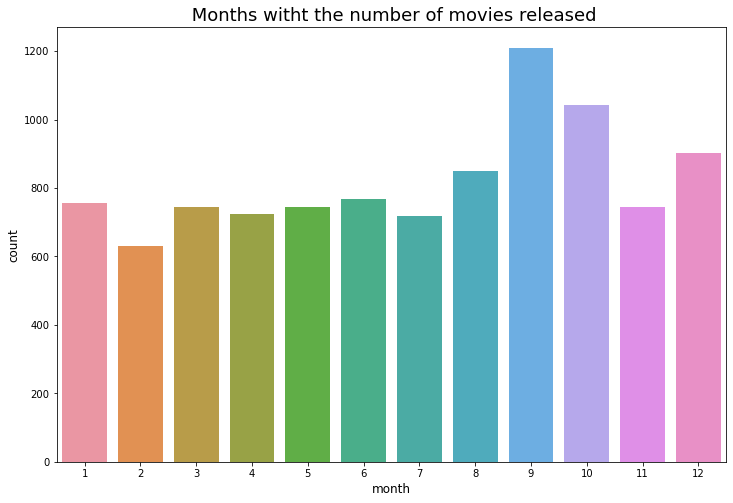

```python
# count plot along y axis
plt.figure(figsize = [12, 8])
plt.title(" Months witht the number of movies released", fontsize=18); plt.ylabel('count of movies',fontsize=12);
plt.xlabel('Month',fontsize=12);
sn.countplot(x ='month', data = df)

# Show the plot
plt.show()
```

#### ANS_Q1: The month with the most movies released on it was September.

### Q2: What is the popular vote average for the movies?

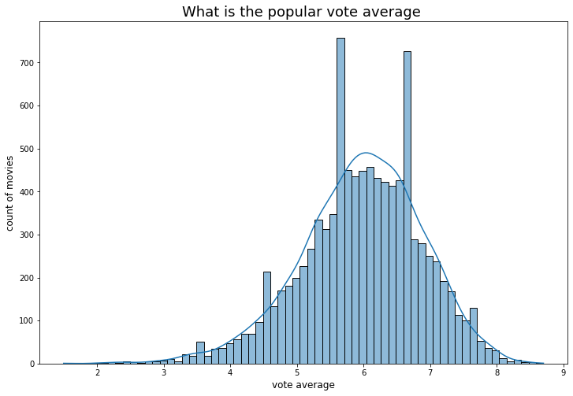

```python
plt.figure(figsize = [12, 8])
plt.title("What is the popular vote average ", fontsize=18); plt.ylabel('count of movies',fontsize=12);
plt.xlabel('vote average',fontsize=12);

sn.histplot(x='vote_average', data=df, kde=True)
```

##### Ans_Q2 : The interval from 5.8 to 6.8 was the most popular vote average for all movies

### Q3: How many number of the movies get good result of the vote rate(Including number of gains and losses?

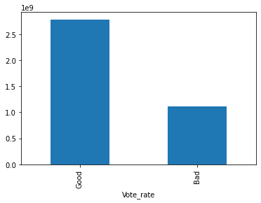

```python
df.groupby("Vote_rate").revenue.max().sort_values(ascending=False)[:5].plot.bar()
```

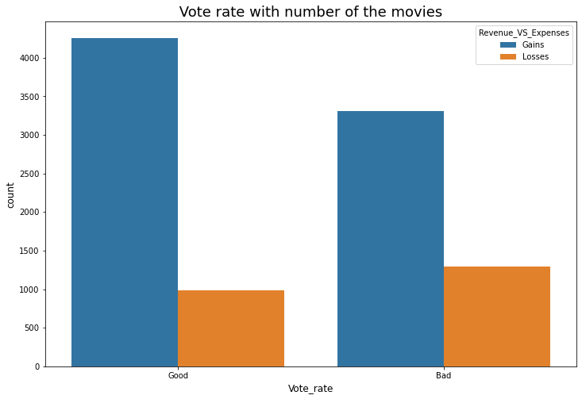

```python
plt.figure(figsize = [12, 8])
plt.title(" Vote rate with number of the movies ", fontsize=18); plt.ylabel('count of movies',fontsize=12);
plt.xlabel('Vote rate',fontsize=12);
# count plot along y axis
sn.countplot(x ='Vote_rate', hue = "Revenue_VS_Expenses", data = df)

# Show the plot
plt.show()
```

#### Ans_Q3: there is 5000 movies get good rating Including 4000 movie that was gains and 1000 movie that losses

### What is the most common runtime interval for all movies?

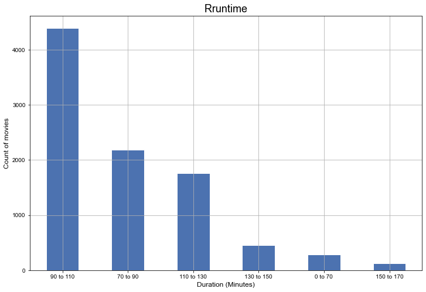

```python
# Bar chart for runtime
plt.figure(figsize = [12, 8])
plt.title(" Rruntime ", fontsize=18); plt.ylabel('Count of movies',fontsize=12);
plt.xlabel('Duration (Minutes)',fontsize=12);

sn.set(font_scale=1.4)
df['runtime'].value_counts().plot(kind='bar', rot=0)
```

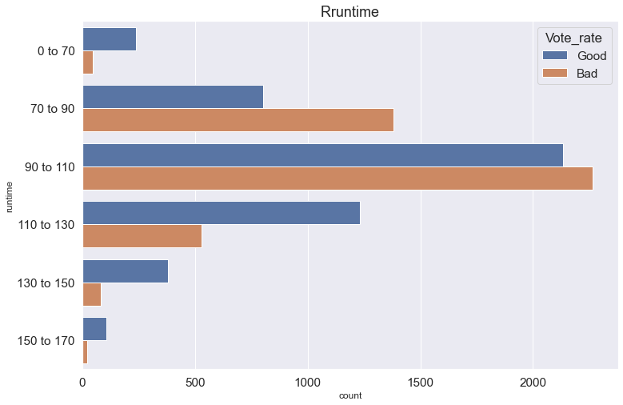

```python
# Bar chart for runtime
plt.figure(figsize = [12, 8])
plt.title(" Rruntime ", fontsize=18); plt.ylabel('Count of movies',fontsize=12);
plt.xlabel('Duration (Minutes)',fontsize=12);
# count plot along y axis
sn.countplot(y ='runtime', hue = "Vote_rate", data = df)

# Show the plot
plt.show()
```

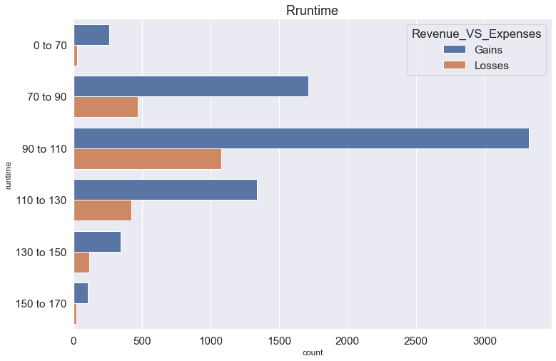

```python
# Bar chart for runtime
plt.figure(figsize = [12, 8])
plt.title(" Rruntime ", fontsize=18); plt.ylabel('Count of movies',fontsize=12);
plt.xlabel('Duration (Minutes)',fontsize=12);
# count plot along y axis
sn.countplot(y ='runtime', hue = "Revenue_VS_Expenses", data = df)

# Show the plot
plt.show()
```

### Q5: What is the most genre popular?

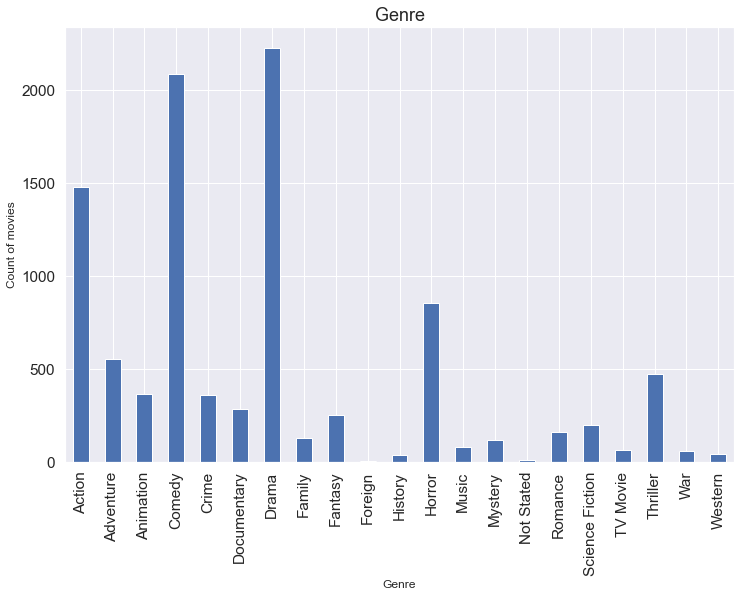

```python
plt.figure(figsize = [12, 8])
plt.title(" Genre ", fontsize=18); plt.ylabel('Count of movies',fontsize=12);
plt.xlabel('Genre',fontsize=12);
df['genre_1'].value_counts().sort_index().plot.bar(figsize=(12,8))
```

#### Ans_Q5: the drama was the most popular genre, followed by comedy.

### Q6: Was there a change in the number of movies released over time?

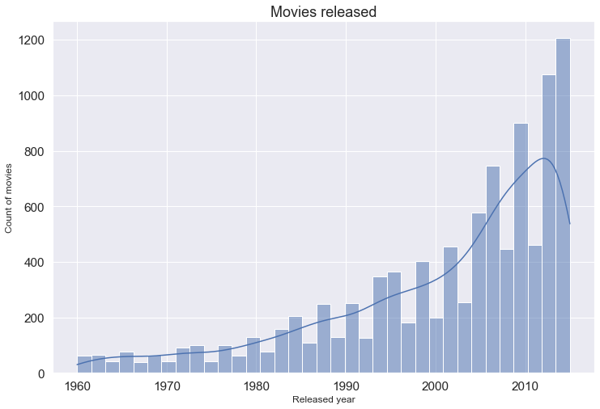

```python
plt.figure(figsize = [12, 8])
plt.title(" Movies released ", fontsize=18); plt.ylabel('Count of movies',fontsize=12);
plt.xlabel('Released year',fontsize=12);
sn.histplot(x='release_year', data=df, kde=True)

plt.show()
```

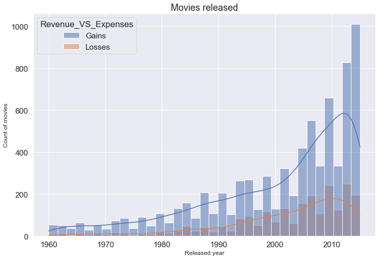

```python
plt.figure(figsize = [12, 8])
plt.title(" Movies released ", fontsize=18); plt.ylabel('Count of movies',fontsize=12);
plt.xlabel('Released year',fontsize=12);

sn.histplot(x='release_year', data=df, kde=True, hue='Revenue_VS_Expenses')

plt.show()
```

#### Ans_Q6: for sure there is an effect on movies released over time and of course will be increas due to the development of instruments and the presence of contemporary technology, which aid in and significantly reduce the amount of time it takes to make a movie, and we can see effect of the gains and losses with the nunber movies released over time.

## Conclusions

> After analyzing the data, it was determined that the month with the most movies produced was September, the interval from 5.8 to 6.8 was the most popular vote average for all movies, there is 5000 movies get good ratings Including 4000 movies that was gains and 1000 movies that losses, the most popular interval runtime were between 90 to 110 per minute, the drama was the most popular genre, followed by comedy.

#### Resources:

- https://pandas.pydata.org/docs/index.html
- https://www.dataquest.io/blog/plot-dataframe-pandas/
- https://www.geeksforgeeks.org/countplot-using-seaborn-in-python/
- https://www.simplilearn.com/tutorials/python-tutorial/data-visualization-in-python
- https://stackoverflow.com/